# Session 4 - Introduction to the Tidyverse - Statistics

#### 3.1.4.2 “coef” and “coefficients”

```r
coef(mdl.lm)[1] # same as mdl.lm$coefficients[1]
```

```
(Intercept)
   6.439237
```

```r
coef(mdl.lm)[2] # same as mdl.lm$coefficients[2]
```

```
AgeSubjectold
    0.2217215
```

```r
summary(mdl.lm)$coefficients[2, ] # full row
```

```
   Estimate  Std. Error     t value    Pr(>|t|)
 0.22172146  0.00328631 67.46820211  0.00000000
```

```r
summary(mdl.lm)$coefficients[2, 4] #for p value
```

```
[1] 0
```

#### 3.1.4.3 Residuals

What about residuals (difference between the observed value and the estimated value of the quantity) and fitted values? This allows us to evaluate how normal our residuals are and how different they are from a normal distribution.

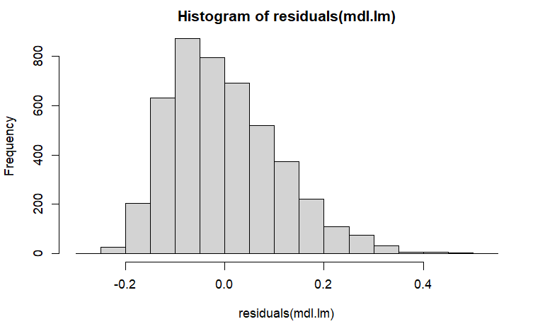

```r
hist(residuals(mdl.lm))
```

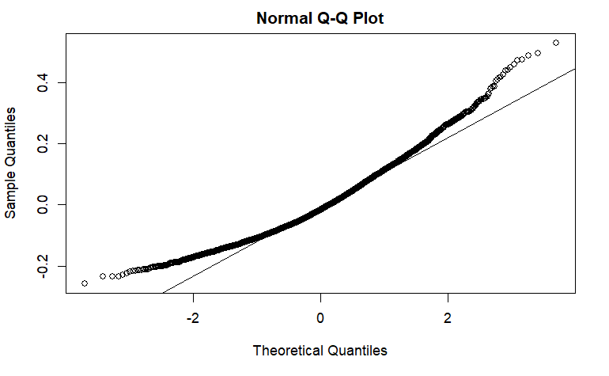

```r
qqnorm(residuals(mdl.lm)); qqline(residuals(mdl.lm))
```

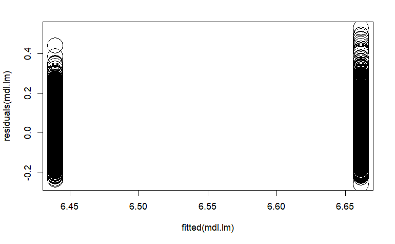

```r
plot(fitted(mdl.lm), residuals(mdl.lm), cex = 4)
```

#### 3.1.4.4 Goodness of fit?

```r
AIC(mdl.lm) # Akaike's Information Criterion, lower values are better
```

```
[1] -7110.962
```

```r
BIC(mdl.lm) # Bayesian AIC
```

```
[1] -7091.682
```

```r
logLik(mdl.lm)  # log likelihood
```

```
'log Lik.' 3558.481 (df=3)
```

Or use the following from `broom`

```r
glance(mdl.lm)
```

| r.squared | adj.r.squared | sigma | statistic | p.value | df | logLik | AIC | BIC | deviance | df.residual | nobs |
| --- | --- | --- | --- | --- | --- | --- | --- | --- | --- | --- | --- |
| 0.49923 | 0.4991203 | 0.1110559 | 4551.958 | 0 | 1 | 3558.481 | -7110.962 | -7091.682 | 56.31437 | 4566 | 4568 |

#### 3.1.4.5 Significance testing

Are the above informative? of course not directly. If we want to test for overall significance of model. We run a null model (aka intercept only) and compare models.

```r
mdl.lm.Null <- english %>%
  lm(RTlexdec ~ 1, data = .)
mdl.comp <- anova(mdl.lm.Null, mdl.lm)
mdl.comp
```

```
Analysis of Variance Table

Model 1: RTlexdec ~ 1
Model 2: RTlexdec ~ AgeSubject
  Res.Df     RSS Df Sum of Sq    F    Pr(>F)
1   4567 112.456
2   4566  56.314  1    56.141 4552 < 2.2e-16 ***
---
Signif. codes:  0 ‘***’ 0.001 ‘**’ 0.01 ‘*’ 0.05 ‘.’ 0.1 ‘ ’ 1
```

The results show that adding the variable “AgeSubject” improves the model fit. We can write this as follows: Model comparison showed that the addition of AgeSubject improved the model fit when compared with an intercept only model ($F$(1) = 4551.96, *p* < 0) (F(1) = 4552 , p < 2.2e-16)

#### 3.1.4.6 Add significance levels and trend line on a plot?

We can use the p values generated from either our linear model to add significance levels on a plot. We use the code from above and add the significance level. We also add a trend line

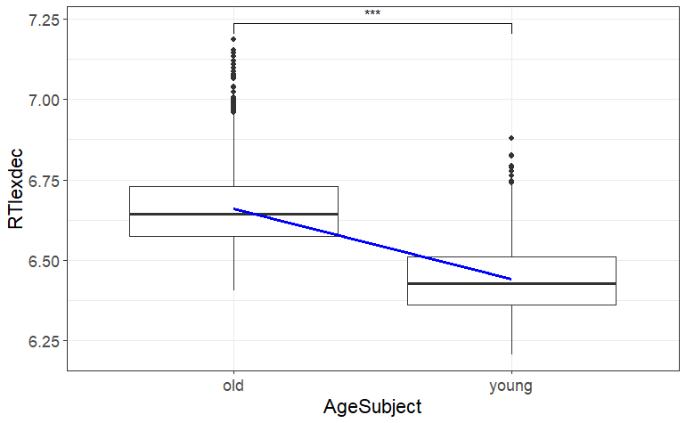

```r
english %>%
  ggplot(aes(x = AgeSubject, y = RTlexdec))+
  geom_boxplot()+
  theme_bw() + theme(text = element_text(size = 15))+
  geom_smooth(aes(x = as.numeric(AgeSubject), y = predict(mdl.lm)), method = "lm", color = "blue") +
  geom_signif(comparison = list(c("old", "young")),
              map_signif_level = TRUE, test = function(a, b) {
                list(p.value = summary(mdl.lm)$coefficients[2, 4]
)})
```

## 3.2 Multiple predictors?

Linear models require a numeric outcome, but the predictor can be either numeric or a factor. We can have more than one predictor. The only issue is that this complicates the interpretation of results

```r
english %>%
  lm(RTlexdec ~ AgeSubject * WordCategory, data = .) %>%
  summary()
```

```
Call:
lm(formula = RTlexdec ~ AgeSubject * WordCategory, data = .)

Residuals:
     Min       1Q   Median       3Q      Max
-0.25079 -0.08273 -0.01516  0.06940  0.52285

Coefficients:
                               Estimate Std. Error  t value Pr(>|t|)
(Intercept)                    6.664955   0.002911 2289.950   <2e-16
AgeSubjectyoung               -0.220395   0.004116  -53.545   <2e-16
WordCategoryV                 -0.010972   0.004822   -2.275   0.0229
AgeSubjectyoung:WordCategoryV -0.003642   0.006820   -0.534   0.5934

(Intercept)                   ***
AgeSubjectyoung               ***
WordCategoryV                 *
AgeSubjectyoung:WordCategoryV
---
Signif. codes:  0 ‘***’ 0.001 ‘**’ 0.01 ‘*’ 0.05 ‘.’ 0.1 ‘ ’ 1

Residual standard error: 0.1109 on 4564 degrees of freedom
Multiple R-squared:  0.5008,    Adjusted R-squared:  0.5005
F-statistic:  1526 on 3 and 4564 DF,  p-value: < 2.2e-16
```

And with an Anova

```r
english %>%
  lm(RTlexdec ~ AgeSubject * WordCategory, data = .) %>%
  anova()
```

```
Analysis of Variance Table

Response: RTlexdec
                          Df Sum Sq Mean Sq   F value    Pr(>F)
AgeSubject                 1 56.141  56.141 4564.2810 < 2.2e-16 ***
WordCategory               1  0.173   0.173   14.0756 0.0001778 ***
AgeSubject:WordCategory    1  0.004   0.004    0.2851 0.5933724
Residuals               4564 56.138   0.012
---
Signif. codes:  0 ‘***’ 0.001 ‘**’ 0.01 ‘*’ 0.05 ‘.’ 0.1 ‘ ’ 1
```

# 4 End of the session